# Can Statistics Detect Fake Data?

## 5.2 4.2 Hypotheses and decision rule

$$H_0: \text{the observed first-digit
distribution is consistent with the Benford distribution}$$
$$H_1: \text{the observed first-digit distribution
differs from the Benford distribution}$$

with the Pearson statistic

$$X^2 = \sum_{d=1}^{9} \frac{(O_d -
E_d)^2}{E_d}, \qquad \mathrm{df} = 9 - 1 = 8,$$

and $H_0$ rejected when $p < \alpha = 0.05$. Two distributions are kept strictly separate throughout: the **observed** distribution comes from the data, the **expected** distribution comes from the formula.

## 5.3 4.3 Validity rules (never silently violated)

- **Reliable** - every expected count $E \ge 5$.
- **Caution** - every $E \ge 1$ and at most 20% of the classes have $E < 5$ (Cochran’s rule).
- **Not run** - any $E < 1$, or $N < 50$, or more than 20% of classes with $E < 5$; the statistic and p-value are returned as `NA` together with a plain-language reason.

Because the smallest first-digit probability is $P(9) = 0.04576$, the first-digit test needs $N \ge 110$ for every expected count to reach 5, and $N \ge 22$ for every expected count to reach 1. The corresponding thresholds for the first-two-digit and second-digit tests are computed in code from their own probability vectors.

## 5.4 4.4 Practical deviation measures

Chi-square becomes oversensitive for large $N$, so every result also reports

- per-digit observed and expected proportions, their difference and the standardised (Pearson) residual $(O-E)/\sqrt{E}$, with $|\,$residual$| > 1.96$ marked as notable (a screening heuristic);
- the mean absolute deviation $\mathrm{MAD} = \frac{1}{9}\sum |p_{\text{obs}} - p_{\text{exp}}|$ with the **Nigrini first-digit bands** (close conformity $\le 0.006$, acceptable $\le 0.012$, marginal $\le 0.015$, nonconformity above 0.015) - these bands apply to the **first digit only**, so only the raw MAD is reported for the other digit classes;
- Cohen’s $w = \sqrt{X^2/N}$ as the effect size.

## 5.5 4.5 Multiple testing

Results are grouped into pre-declared families: latest-complete-year cross-sections, pooled country-years, all per-year subsets, and all per-region subsets. Within each family, raw, Holm and Benjamini-Hochberg adjusted p-values are reported and **the flags use the BH-adjusted p-value**. The family definition is stored in the `family` column of `chi_square_results.csv`.

## 5.6 4.6 Anomaly flag (single decision function)

The flag is one of exactly five categories: *not assessed - unsuitable data*, *not assessed - insufficient sample*, *statistical deviation: significant AND practically material* (adjusted $p < \alpha$ **and** MAD above the 0.006 conformity band), *statistically significant but small deviation*, or *no significant deviation detected*. Each flag carries a one-sentence interpretation that repeats the boundary statement.

## 5.7 4.7 Suitability screening

Every column is screened before testing: sample size, dynamic range in orders of magnitude, positive skew, uniqueness, integer/code-like structure, bounded or percentage-like ranges, hard ceilings, heavy rounding and identifier-like column names. Columns that fail are **not** flagged; they are explained.

# 6 5. Results

## 6.1 5.1 Data cleaning

Cleaning decisions per indicator (pooled country-years). The panel keeps only real countries: rows whose Country Code has a non-empty Region in WDICountry.csv.

| indicator_code | total_values | missing_NA_NaN | non_finite_Inf | invalid_non_numeric | zero_excluded | negative_used_as_magnitude | eligible_values |
| --- | --- | --- | --- | --- | --- | --- | --- |
| AG.LND.TOTL.K2 | 12349 | 0 | 0 | 0 | 0 | 0 | 12349 |
| FI.RES.TOTL.CD | 9464 | 0 | 0 | 0 | 0 | 0 | 9464 |
| NE.EXP.GNFS.CD | 9024 | 0 | 0 | 0 | 0 | 0 | 9024 |
| NE.IMP.GNFS.CD | 9033 | 0 | 0 | 0 | 0 | 0 | 9033 |
| NY.GDP.MKTP.CD | 11764 | 0 | 0 | 0 | 0 | 0 | 11764 |
| NY.GNP.MKTP.CD | 11234 | 0 | 0 | 0 | 0 | 0 | 11234 |
| SP.DYN.LE00.IN | 14071 | 0 | 0 | 0 | 0 | 0 | 14071 |
| SP.DYN.TFRT.IN | 14073 | 0 | 0 | 0 | 0 | 0 | 14073 |
| SP.POP.TOTL | 14292 | 0 | 0 | 0 | 0 | 0 | 14292 |
| USASPEND.CURRENT_TOTAL_VALUE_OF_AWARD | 110044 | 0 | 0 | 0 | 0 | 0 | 110044 |
| USASPEND.FEDERAL_ACTION_OBLIGATION | 101381 | 0 | 0 | 0 | 0 | 0 | 101381 |
| USASPEND.POTENTIAL_TOTAL_VALUE_OF_AWARD | 110253 | 0 | 0 | 0 | 0 | 0 | 110253 |

## 6.2 5.2 Descriptive statistics

The table below is the pooled country-year summary for each indicator (the complete per-unit version, including every year and region, is in `outputs/tables/descriptive_statistics.csv`).

Descriptive statistics of the pooled country-year values (base-R moment skewness).

| Indicator | N | Min | Median | Mean | Max | SD | Q1 | Q3 | Skewness | Range_orders | pct_unique |
| --- | --- | --- | --- | --- | --- | --- | --- | --- | --- | --- | --- |
| Land area (sq. km) | 12349 | 2.0270e+00 | 1.0025e+05 | 5.9364e+05 | 1.6390e+07 | 1.641e+06 | 1.0010e+04 | 4.5286e+05 | 5.480 | 6.9 | 0.0658 |
| Total reserves incl. gold (current USD) | 9464 | 1.0000e+04 | 1.2057e+09 | 3.0338e+10 | 3.9000e+12 | 1.704e+11 | 1.8108e+08 | 9.3347e+09 | 15.000 | 8.6 | 0.9960 |
| Exports of goods and services (current USD) | 9024 | 6.9328e+05 | 4.1991e+09 | 6.6666e+10 | 4.1085e+12 | 2.243e+11 | 7.6203e+08 | 2.8396e+10 | 7.880 | 6.8 | 0.9970 |
| Imports of goods and services (current USD) | 9033 | 1.8496e+06 | 5.0783e+09 | 6.5171e+10 | 4.1138e+12 | 2.285e+11 | 1.0487e+09 | 2.7602e+10 | 8.510 | 6.3 | 0.9980 |
| GDP (current USD) | 11764 | 2.5860e+06 | 8.2309e+09 | 2.0092e+11 | 3.0770e+13 | 1.144e+12 | 1.4793e+09 | 5.3582e+10 | 14.400 | 7.1 | 1.0000 |
| GNI (current USD) | 11234 | 5.0790e+06 | 8.8544e+09 | 2.0928e+11 | 3.0586e+13 | 1.174e+12 | 1.5515e+09 | 5.6058e+10 | 14.000 | 6.8 | 1.0000 |
| Life expectancy at birth (years) | 14071 | 1.0989e+01 | 6.8006e+01 | 6.5362e+01 | 8.6497e+01 | 1.124e+01 | 5.8612e+01 | 7.3493e+01 | -0.768 | 0.9 | 0.8850 |
| Fertility rate, total (births per woman) | 14073 | 5.8200e-01 | 3.2080e+00 | 3.7876e+00 | 8.8640e+00 | 1.989e+00 | 2.0060e+00 | 5.6440e+00 | 0.453 | 1.2 | 0.4000 |
| Population, total | 14292 | 2.7150e+03 | 4.2783e+06 | 2.5498e+07 | 1.4639e+09 | 1.063e+08 | 5.0193e+05 | 1.4146e+07 | 9.760 | 5.7 | 0.9970 |
| USASpending current_total_value_of_award (usaspending.csv) | 110044 | 1.0000e-02 | 7.4033e+04 | 3.7910e+06 | 8.8331e+09 | 8.473e+07 | 1.9306e+04 | 3.6987e+05 | 83.100 | 12.0 | 0.7880 |
| USASpending federal_action_obligation (usaspending.csv) | 101381 | 1.0000e-02 | 2.6473e+04 | 7.1133e+05 | 1.3653e+09 | 1.640e+07 | 1.1958e+04 | 9.6040e+04 | 45.100 | 11.0 | 0.8000 |
| USASpending potential_total_value_of_award (usaspending.csv) | 110253 | 1.0000e-02 | 9.3007e+04 | 6.3434e+06 | 8.8331e+09 | 1.270e+08 | 2.0874e+04 | 4.6913e+05 | 51.000 | 12.0 | 0.7790 |

Distribution shape is shown graphically; a Benford-conforming variable is roughly uniform on the log scale, which is exactly the point of the law.

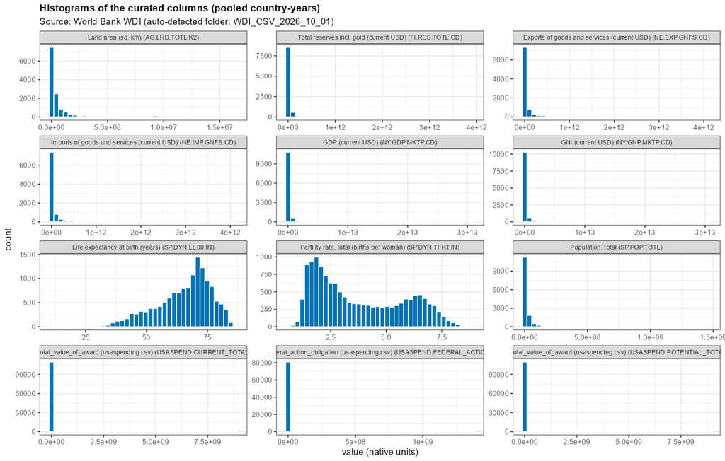

Histograms of the curated columns (pooled country-years).

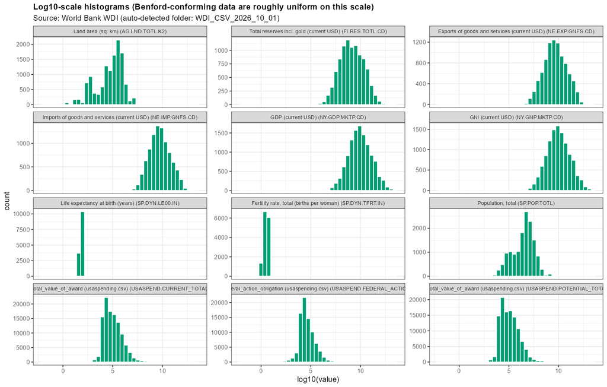

The same columns on a log10 scale: Benford-conforming variables are roughly uniform on this scale.